# Risk Factor Analysis

## Outcome Variable

**Outcome Variable:** y_rate_haz

## Predictor Variables

**Intervention Variable:** hdlvry

**Adjustment Set:**

unadjusted

## Stratifying Variables

The analysis was stratified on these variable(s):

- agecat
- studyid
- country

## Data Summary

| agecat | studyid | country | hdlvry | n_cell | n |
| --- | --- | --- | --- | --- | --- |
| 0-3 months | ki1017093b-PROVIDE | BANGLADESH | 0 | 474 | 634 |
| 0-3 months | ki1017093b-PROVIDE | BANGLADESH | 1 | 160 | 634 |
| 0-3 months | ki1017093c-NIH-Crypto | BANGLADESH | 0 | 557 | 720 |
| 0-3 months | ki1017093c-NIH-Crypto | BANGLADESH | 1 | 163 | 720 |
| 0-3 months | kiGH5241-JiVitA-3 | BANGLADESH | 0 | 33 | 313 |
| 0-3 months | kiGH5241-JiVitA-3 | BANGLADESH | 1 | 280 | 313 |
| 0-3 months | kiGH5241-JiVitA-4 | BANGLADESH | 0 | 369 | 1796 |
| 0-3 months | kiGH5241-JiVitA-4 | BANGLADESH | 1 | 1427 | 1796 |
| 0-3 months | ki1000108-CMC-V-BCS-2002 | INDIA | 0 | 87 | 87 |
| 0-3 months | ki1000108-IRC | INDIA | 0 | 370 | 377 |
| 0-3 months | ki1000108-IRC | INDIA | 1 | 7 | 377 |
| 0-3 months | ki1000304b-SAS-CompFeed | INDIA | 0 | 127 | 976 |
| 0-3 months | ki1000304b-SAS-CompFeed | INDIA | 1 | 849 | 976 |
| 0-3 months | ki1135781-COHORTS | INDIA | 0 | 2863 | 4580 |
| 0-3 months | ki1135781-COHORTS | INDIA | 1 | 1717 | 4580 |
| 0-3 months | ki1000109-EE | PAKISTAN | 0 | 193 | 295 |
| 0-3 months | ki1000109-EE | PAKISTAN | 1 | 102 | 295 |
| 3-6 months | ki1017093b-PROVIDE | BANGLADESH | 0 | 428 | 574 |
| 3-6 months | ki1017093b-PROVIDE | BANGLADESH | 1 | 146 | 574 |
| 3-6 months | ki1017093c-NIH-Crypto | BANGLADESH | 0 | 536 | 695 |
| 3-6 months | ki1017093c-NIH-Crypto | BANGLADESH | 1 | 159 | 695 |
| 3-6 months | kiGH5241-JiVitA-3 | BANGLADESH | 0 | 28 | 275 |
| 3-6 months | kiGH5241-JiVitA-3 | BANGLADESH | 1 | 247 | 275 |
| 3-6 months | kiGH5241-JiVitA-4 | BANGLADESH | 0 | 412 | 1752 |
| 3-6 months | kiGH5241-JiVitA-4 | BANGLADESH | 1 | 1340 | 1752 |
| 3-6 months | ki1000108-CMC-V-BCS-2002 | INDIA | 0 | 298 | 305 |
| 3-6 months | ki1000108-CMC-V-BCS-2002 | INDIA | 1 | 7 | 305 |
| 3-6 months | ki1000108-IRC | INDIA | 0 | 389 | 397 |
| 3-6 months | ki1000108-IRC | INDIA | 1 | 8 | 397 |
| 3-6 months | ki1000304b-SAS-CompFeed | INDIA | 0 | 124 | 919 |
| 3-6 months | ki1000304b-SAS-CompFeed | INDIA | 1 | 795 | 919 |
| 3-6 months | ki1135781-COHORTS | INDIA | 0 | 2754 | 4481 |
| 3-6 months | ki1135781-COHORTS | INDIA | 1 | 1727 | 4481 |
| 3-6 months | ki1113344-GMS-Nepal | NEPAL | 0 | 102 | 438 |
| 3-6 months | ki1113344-GMS-Nepal | NEPAL | 1 | 336 | 438 |
| 3-6 months | ki1000109-EE | PAKISTAN | 0 | 218 | 329 |
| 3-6 months | ki1000109-EE | PAKISTAN | 1 | 111 | 329 |
| 3-6 months | ki1066203-TanzaniaChild2 | TANZANIA, UNITED REPUBLIC OF | 0 | 1549 | 1577 |
| 3-6 months | ki1066203-TanzaniaChild2 | TANZANIA, UNITED REPUBLIC OF | 1 | 28 | 1577 |
| 6-12 months | ki1017093b-PROVIDE | BANGLADESH | 0 | 404 | 545 |
| 6-12 months | ki1017093b-PROVIDE | BANGLADESH | 1 | 141 | 545 |
| 6-12 months | ki1017093c-NIH-Crypto | BANGLADESH | 0 | 523 | 676 |
| 6-12 months | ki1017093c-NIH-Crypto | BANGLADESH | 1 | 153 | 676 |
| 6-12 months | kiGH5241-JiVitA-3 | BANGLADESH | 0 | 29 | 243 |
| 6-12 months | kiGH5241-JiVitA-3 | BANGLADESH | 1 | 214 | 243 |
| 6-12 months | kiGH5241-JiVitA-4 | BANGLADESH | 0 | 750 | 2803 |
| 6-12 months | kiGH5241-JiVitA-4 | BANGLADESH | 1 | 2053 | 2803 |
| 6-12 months | ki1000108-CMC-V-BCS-2002 | INDIA | 0 | 314 | 321 |
| 6-12 months | ki1000108-CMC-V-BCS-2002 | INDIA | 1 | 7 | 321 |
| 6-12 months | ki1000108-IRC | INDIA | 0 | 392 | 400 |
| 6-12 months | ki1000108-IRC | INDIA | 1 | 8 | 400 |
| 6-12 months | ki1000304b-SAS-CompFeed | INDIA | 0 | 131 | 936 |
| 6-12 months | ki1000304b-SAS-CompFeed | INDIA | 1 | 805 | 936 |
| 6-12 months | ki1000304b-SAS-FoodSuppl | INDIA | 0 | 67 | 332 |
| 6-12 months | ki1000304b-SAS-FoodSuppl | INDIA | 1 | 265 | 332 |
| 6-12 months | ki1135781-COHORTS | INDIA | 0 | 2239 | 3598 |
| 6-12 months | ki1135781-COHORTS | INDIA | 1 | 1359 | 3598 |
| 6-12 months | ki1113344-GMS-Nepal | NEPAL | 0 | 105 | 446 |
| 6-12 months | ki1113344-GMS-Nepal | NEPAL | 1 | 341 | 446 |
| 6-12 months | ki1000109-EE | PAKISTAN | 0 | 4 | 4 |
| 6-12 months | ki1066203-TanzaniaChild2 | TANZANIA, UNITED REPUBLIC OF | 0 | 1015 | 1025 |
| 6-12 months | ki1066203-TanzaniaChild2 | TANZANIA, UNITED REPUBLIC OF | 1 | 10 | 1025 |
| 12-24 months | ki1017093b-PROVIDE | BANGLADESH | 0 | 340 | 458 |
| 12-24 months | ki1017093b-PROVIDE | BANGLADESH | 1 | 118 | 458 |
| 12-24 months | ki1017093c-NIH-Crypto | BANGLADESH | 0 | 379 | 495 |
| 12-24 months | ki1017093c-NIH-Crypto | BANGLADESH | 1 | 116 | 495 |
| 12-24 months | kiGH5241-JiVitA-3 | BANGLADESH | 0 | 24 | 191 |
| 12-24 months | kiGH5241-JiVitA-3 | BANGLADESH | 1 | 167 | 191 |
| 12-24 months | kiGH5241-JiVitA-4 | BANGLADESH | 0 | 805 | 3107 |
| 12-24 months | kiGH5241-JiVitA-4 | BANGLADESH | 1 | 2302 | 3107 |
| 12-24 months | ki1000108-CMC-V-BCS-2002 | INDIA | 0 | 315 | 322 |
| 12-24 months | ki1000108-CMC-V-BCS-2002 | INDIA | 1 | 7 | 322 |
| 12-24 months | ki1000108-IRC | INDIA | 0 | 388 | 396 |
| 12-24 months | ki1000108-IRC | INDIA | 1 | 8 | 396 |
| 12-24 months | ki1135781-COHORTS | INDIA | 0 | 1876 | 2999 |
| 12-24 months | ki1135781-COHORTS | INDIA | 1 | 1123 | 2999 |
| 12-24 months | ki1113344-GMS-Nepal | NEPAL | 0 | 86 | 341 |
| 12-24 months | ki1113344-GMS-Nepal | NEPAL | 1 | 255 | 341 |
| 12-24 months | ki1066203-TanzaniaChild2 | TANZANIA, UNITED REPUBLIC OF | 0 | 2 | 2 |

The following strata were considered:

- agecat: 0-3 months, studyid: ki1000108-CMC-V-BCS-2002, country: INDIA
- agecat: 0-3 months, studyid: ki1000108-IRC, country: INDIA
- agecat: 0-3 months, studyid: ki1000109-EE, country: PAKISTAN
- agecat: 0-3 months, studyid: ki1000304b-SAS-CompFeed, country: INDIA
- agecat: 0-3 months, studyid: ki1017093b-PROVIDE, country: BANGLADESH
- agecat: 0-3 months, studyid: ki1017093c-NIH-Crypto, country: BANGLADESH
- agecat: 0-3 months, studyid: ki1135781-COHORTS, country: INDIA
- agecat: 0-3 months, studyid: kiGH5241-JiVitA-3, country: BANGLADESH
- agecat: 0-3 months, studyid: kiGH5241-JiVitA-4, country: BANGLADESH
- agecat: 12-24 months, studyid: ki1000108-CMC-V-BCS-2002, country: INDIA
- agecat: 12-24 months, studyid: ki1000108-IRC, country: INDIA
- agecat: 12-24 months, studyid: ki1017093b-PROVIDE, country: BANGLADESH
- agecat: 12-24 months, studyid: ki1017093c-NIH-Crypto, country: BANGLADESH
- agecat: 12-24 months, studyid: ki1066203-TanzaniaChild2, country: TANZANIA, UNITED REPUBLIC OF
- agecat: 12-24 months, studyid: ki1113344-GMS-Nepal, country: NEPAL
- agecat: 12-24 months, studyid: ki1135781-COHORTS, country: INDIA
- agecat: 12-24 months, studyid: kiGH5241-JiVitA-3, country: BANGLADESH
- agecat: 12-24 months, studyid: kiGH5241-JiVitA-4, country: BANGLADESH
- agecat: 3-6 months, studyid: ki1000108-CMC-V-BCS-2002, country: INDIA
- agecat: 3-6 months, studyid: ki1000108-IRC, country: INDIA
- agecat: 3-6 months, studyid: ki1000109-EE, country: PAKISTAN
- agecat: 3-6 months, studyid: ki1000304b-SAS-CompFeed, country: INDIA
- agecat: 3-6 months, studyid: ki1017093b-PROVIDE, country: BANGLADESH
- agecat: 3-6 months, studyid: ki1017093c-NIH-Crypto, country: BANGLADESH
- agecat: 3-6 months, studyid: ki1066203-TanzaniaChild2, country: TANZANIA, UNITED REPUBLIC OF
- agecat: 3-6 months, studyid: ki1113344-GMS-Nepal, country: NEPAL
- agecat: 3-6 months, studyid: ki1135781-COHORTS, country: INDIA
- agecat: 3-6 months, studyid: kiGH5241-JiVitA-3, country: BANGLADESH
- agecat: 3-6 months, studyid: kiGH5241-JiVitA-4, country: BANGLADESH
- agecat: 6-12 months, studyid: ki1000108-CMC-V-BCS-2002, country: INDIA
- agecat: 6-12 months, studyid: ki1000108-IRC, country: INDIA
- agecat: 6-12 months, studyid: ki1000109-EE, country: PAKISTAN
- agecat: 6-12 months, studyid: ki1000304b-SAS-CompFeed, country: INDIA
- agecat: 6-12 months, studyid: ki1000304b-SAS-FoodSuppl, country: INDIA
- agecat: 6-12 months, studyid: ki1017093b-PROVIDE, country: BANGLADESH
- agecat: 6-12 months, studyid: ki1017093c-NIH-Crypto, country: BANGLADESH
- agecat: 6-12 months, studyid: ki1066203-TanzaniaChild2, country: TANZANIA, UNITED REPUBLIC OF
- agecat: 6-12 months, studyid: ki1113344-GMS-Nepal, country: NEPAL
- agecat: 6-12 months, studyid: ki1135781-COHORTS, country: INDIA
- agecat: 6-12 months, studyid: kiGH5241-JiVitA-3, country: BANGLADESH
- agecat: 6-12 months, studyid: kiGH5241-JiVitA-4, country: BANGLADESH

### Dropped Strata

Some strata were dropped due to rare outcomes:

- agecat: 6-12 months, studyid: ki1000109-EE, country: PAKISTAN
- agecat: 12-24 months, studyid: ki1066203-TanzaniaChild2, country: TANZANIA, UNITED REPUBLIC OF

## Methods Detail

We’re interested in the causal parameters $E[Y_a]$ for all values of $a \in \mathcal{A}$. These parameters represent the mean outcome if, possibly contrary to fact, we intervened to set all units to have $A=a$. Under the randomization and positivity assumptions, these are identified by the statistical parameters $\psi_a=E_W[E_{Y|A,W}(Y|A=a,W)]$. In addition, we’re interested in the mean of $Y$, $E[Y]$ under no intervention (the observed mean). We will estimate these parameters by using SuperLearner to fit the relevant likelihood factors – $E_{Y|A,W}(Y|A=a,W)$ and $p(A=a|W)$, and then updating our likelihood fit using a joint TMLE.

For unadjusted analyses ($W=\{\}$), initial likelihoods were estimated using Lrnr_glm to estimate the simple $E(Y|A)$ and Lrnr_mean to estimate $p(A)$. For adjusted analyses, a small library containing Lrnr_glmnet, Lrnr_xgboost, and Lrnr_mean was used.

Having estimated these parameters, we will then use the delta method to estimate relative risks and attributable risks relative to a prespecified baseline level of $A$.

[output not shown]

[output cut: 49 more lines]

[output not shown]

# Results Detail

## Results Plots

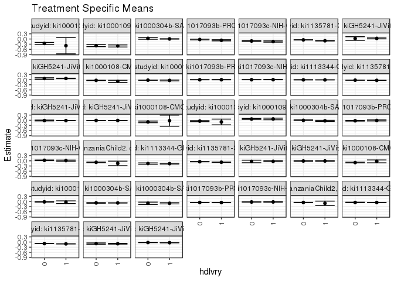

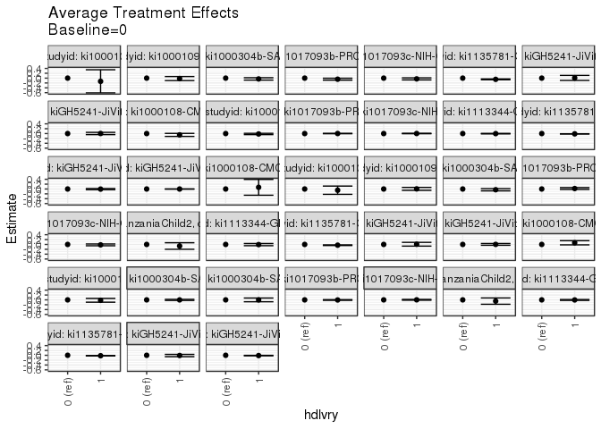

## Results Table

### Parameter: TSM

| agecat | studyid | country | intervention_level | baseline_level | estimate | ci_lower | ci_upper |
| --- | --- | --- | --- | --- | --- | --- | --- |
| 0-3 months | ki1000108-IRC | INDIA | 0 | NA | -0.2570446 | -0.3133181 | -0.2007712 |
| 0-3 months | ki1000108-IRC | INDIA | 1 | NA | -0.3890887 | -0.8631374 | 0.0849601 |
| 0-3 months | ki1000109-EE | PAKISTAN | 0 | NA | -0.3871578 | -0.4443395 | -0.3299761 |
| 0-3 months | ki1000109-EE | PAKISTAN | 1 | NA | -0.4048678 | -0.4652013 | -0.3445344 |
| 0-3 months | ki1000304b-SAS-CompFeed | INDIA | 0 | NA | 0.0376248 | -0.0139335 | 0.0891830 |
| 0-3 months | ki1000304b-SAS-CompFeed | INDIA | 1 | NA | 0.0043839 | -0.0071256 | 0.0158934 |
| 0-3 months | ki1017093b-PROVIDE | BANGLADESH | 0 | NA | -0.0300680 | -0.0513691 | -0.0087669 |
| 0-3 months | ki1017093b-PROVIDE | BANGLADESH | 1 | NA | -0.0746315 | -0.1086256 | -0.0406374 |
| 0-3 months | ki1017093c-NIH-Crypto | BANGLADESH | 0 | NA | -0.1151092 | -0.1360011 | -0.0942173 |
| 0-3 months | ki1017093c-NIH-Crypto | BANGLADESH | 1 | NA | -0.1459098 | -0.1825794 | -0.1092401 |
| 0-3 months | ki1135781-COHORTS | INDIA | 0 | NA | -0.0511395 | -0.0617068 | -0.0405722 |
| 0-3 months | ki1135781-COHORTS | INDIA | 1 | NA | -0.1012847 | -0.1148179 | -0.0877514 |
| 0-3 months | kiGH5241-JiVitA-3 | BANGLADESH | 0 | NA | 0.0268147 | -0.0793486 | 0.1329779 |
| 0-3 months | kiGH5241-JiVitA-3 | BANGLADESH | 1 | NA | 0.0358638 | 0.0073526 | 0.0643750 |
| 0-3 months | kiGH5241-JiVitA-4 | BANGLADESH | 0 | NA | 0.0644870 | 0.0220638 | 0.1069101 |
| 0-3 months | kiGH5241-JiVitA-4 | BANGLADESH | 1 | NA | 0.0677412 | 0.0516917 | 0.0837907 |
| 3-6 months | ki1000108-CMC-V-BCS-2002 | INDIA | 0 | NA | -0.0970669 | -0.1454070 | -0.0487268 |
| 3-6 months | ki1000108-CMC-V-BCS-2002 | INDIA | 1 | NA | -0.0276755 | -0.3500119 | 0.2946609 |
| 3-6 months | ki1000108-IRC | INDIA | 0 | NA | -0.0508820 | -0.0813924 | -0.0203717 |
| 3-6 months | ki1000108-IRC | INDIA | 1 | NA | -0.1009918 | -0.2683302 | 0.0663466 |
| 3-6 months | ki1000109-EE | PAKISTAN | 0 | NA | 0.0691071 | 0.0337732 | 0.1044410 |
| 3-6 months | ki1000109-EE | PAKISTAN | 1 | NA | 0.0743440 | 0.0270057 | 0.1216823 |
| 3-6 months | ki1000304b-SAS-CompFeed | INDIA | 0 | NA | -0.0062338 | -0.0321697 | 0.0197022 |
| 3-6 months | ki1000304b-SAS-CompFeed | INDIA | 1 | NA | -0.0358496 | -0.0673995 | -0.0042996 |
| 3-6 months | ki1017093b-PROVIDE | BANGLADESH | 0 | NA | -0.0320220 | -0.0511816 | -0.0128624 |
| 3-6 months | ki1017093b-PROVIDE | BANGLADESH | 1 | NA | -0.0132325 | -0.0452066 | 0.0187416 |
| 3-6 months | ki1017093c-NIH-Crypto | BANGLADESH | 0 | NA | 0.0307744 | 0.0111518 | 0.0503971 |
| 3-6 months | ki1017093c-NIH-Crypto | BANGLADESH | 1 | NA | 0.0132884 | -0.0186490 | 0.0452258 |
| 3-6 months | ki1066203-TanzaniaChild2 | TANZANIA, UNITED REPUBLIC OF | 0 | NA | -0.0860756 | -0.1032606 | -0.0688905 |
| 3-6 months | ki1066203-TanzaniaChild2 | TANZANIA, UNITED REPUBLIC OF | 1 | NA | -0.1506207 | -0.2839698 | -0.0172717 |
| 3-6 months | ki1113344-GMS-Nepal | NEPAL | 0 | NA | -0.1581992 | -0.1968130 | -0.1195854 |
| 3-6 months | ki1113344-GMS-Nepal | NEPAL | 1 | NA | -0.1649823 | -0.1874439 | -0.1425206 |
| 3-6 months | ki1135781-COHORTS | INDIA | 0 | NA | -0.0512191 | -0.0597589 | -0.0426793 |
| 3-6 months | ki1135781-COHORTS | INDIA | 1 | NA | -0.0814174 | -0.0918884 | -0.0709463 |
| 3-6 months | kiGH5241-JiVitA-3 | BANGLADESH | 0 | NA | -0.0359489 | -0.1106242 | 0.0387264 |
| 3-6 months | kiGH5241-JiVitA-3 | BANGLADESH | 1 | NA | -0.0281992 | -0.0564910 | 0.0000927 |
| 3-6 months | kiGH5241-JiVitA-4 | BANGLADESH | 0 | NA | -0.0104120 | -0.0442624 | 0.0234385 |
| 3-6 months | kiGH5241-JiVitA-4 | BANGLADESH | 1 | NA | -0.0086175 | -0.0236174 | 0.0063824 |
| 6-12 months | ki1000108-CMC-V-BCS-2002 | INDIA | 0 | NA | -0.1006331 | -0.1216225 | -0.0796436 |
| 6-12 months | ki1000108-CMC-V-BCS-2002 | INDIA | 1 | NA | -0.0320275 | -0.1157735 | 0.0517186 |
| 6-12 months | ki1000108-IRC | INDIA | 0 | NA | -0.0256573 | -0.0387196 | -0.0125950 |
| 6-12 months | ki1000108-IRC | INDIA | 1 | NA | -0.0435471 | -0.1211440 | 0.0340497 |
| 6-12 months | ki1000304b-SAS-CompFeed | INDIA | 0 | NA | -0.0854289 | -0.1049513 | -0.0659066 |
| 6-12 months | ki1000304b-SAS-CompFeed | INDIA | 1 | NA | -0.0864163 | -0.0936018 | -0.0792308 |
| 6-12 months | ki1000304b-SAS-FoodSuppl | INDIA | 0 | NA | -0.1072723 | -0.1752556 | -0.0392891 |
| 6-12 months | ki1000304b-SAS-FoodSuppl | INDIA | 1 | NA | -0.1081981 | -0.1430427 | -0.0733534 |
| 6-12 months | ki1017093b-PROVIDE | BANGLADESH | 0 | NA | -0.0615562 | -0.0697751 | -0.0533374 |
| 6-12 months | ki1017093b-PROVIDE | BANGLADESH | 1 | NA | -0.0656492 | -0.0784998 | -0.0527985 |
| 6-12 months | ki1017093c-NIH-Crypto | BANGLADESH | 0 | NA | -0.0320503 | -0.0404914 | -0.0236092 |
| 6-12 months | ki1017093c-NIH-Crypto | BANGLADESH | 1 | NA | -0.0299095 | -0.0442562 | -0.0155629 |
| 6-12 months | ki1066203-TanzaniaChild2 | TANZANIA, UNITED REPUBLIC OF | 0 | NA | -0.0603803 | -0.0697767 | -0.0509839 |
| 6-12 months | ki1066203-TanzaniaChild2 | TANZANIA, UNITED REPUBLIC OF | 1 | NA | -0.1106831 | -0.2403074 | 0.0189412 |
| 6-12 months | ki1113344-GMS-Nepal | NEPAL | 0 | NA | -0.0600948 | -0.0758344 | -0.0443553 |
| 6-12 months | ki1113344-GMS-Nepal | NEPAL | 1 | NA | -0.0628613 | -0.0729520 | -0.0527707 |
| 6-12 months | ki1135781-COHORTS | INDIA | 0 | NA | -0.0897502 | -0.0949622 | -0.0845383 |
| 6-12 months | ki1135781-COHORTS | INDIA | 1 | NA | -0.1068516 | -0.1137820 | -0.0999212 |
| 6-12 months | kiGH5241-JiVitA-3 | BANGLADESH | 0 | NA | -0.0890780 | -0.1264623 | -0.0516936 |
| 6-12 months | kiGH5241-JiVitA-3 | BANGLADESH | 1 | NA | -0.0978751 | -0.1195112 | -0.0762390 |
| 6-12 months | kiGH5241-JiVitA-4 | BANGLADESH | 0 | NA | -0.0291286 | -0.0376940 | -0.0205632 |
| 6-12 months | kiGH5241-JiVitA-4 | BANGLADESH | 1 | NA | -0.0401232 | -0.0453621 | -0.0348843 |
| 12-24 months | ki1000108-CMC-V-BCS-2002 | INDIA | 0 | NA | -0.0450653 | -0.0551951 | -0.0349355 |
| 12-24 months | ki1000108-CMC-V-BCS-2002 | INDIA | 1 | NA | -0.0998494 | -0.1614239 | -0.0382749 |
| 12-24 months | ki1000108-IRC | INDIA | 0 | NA | -0.0314316 | -0.0386198 | -0.0242435 |
| 12-24 months | ki1000108-IRC | INDIA | 1 | NA | -0.0481150 | -0.0746149 | -0.0216151 |
| 12-24 months | ki1017093b-PROVIDE | BANGLADESH | 0 | NA | -0.0086164 | -0.0131194 | -0.0041133 |
| 12-24 months | ki1017093b-PROVIDE | BANGLADESH | 1 | NA | -0.0068907 | -0.0142308 | 0.0004494 |
| 12-24 months | ki1017093c-NIH-Crypto | BANGLADESH | 0 | NA | -0.0062285 | -0.0108923 | -0.0015648 |
| 12-24 months | ki1017093c-NIH-Crypto | BANGLADESH | 1 | NA | -0.0041121 | -0.0117344 | 0.0035102 |
| 12-24 months | ki1113344-GMS-Nepal | NEPAL | 0 | NA | -0.0132068 | -0.0218538 | -0.0045598 |
| 12-24 months | ki1113344-GMS-Nepal | NEPAL | 1 | NA | -0.0157653 | -0.0221391 | -0.0093915 |
| 12-24 months | ki1135781-COHORTS | INDIA | 0 | NA | -0.0319005 | -0.0343311 | -0.0294698 |
| 12-24 months | ki1135781-COHORTS | INDIA | 1 | NA | -0.0440490 | -0.0474212 | -0.0406768 |
| 12-24 months | kiGH5241-JiVitA-3 | BANGLADESH | 0 | NA | -0.0169149 | -0.0422870 | 0.0084572 |
| 12-24 months | kiGH5241-JiVitA-3 | BANGLADESH | 1 | NA | -0.0210767 | -0.0309720 | -0.0111813 |
| 12-24 months | kiGH5241-JiVitA-4 | BANGLADESH | 0 | NA | -0.0135261 | -0.0176141 | -0.0094380 |
| 12-24 months | kiGH5241-JiVitA-4 | BANGLADESH | 1 | NA | -0.0145538 | -0.0168770 | -0.0122305 |

### Parameter: E(Y)

| agecat | studyid | country | intervention_level | baseline_level | estimate | ci_lower | ci_upper |
| --- | --- | --- | --- | --- | --- | --- | --- |
| 0-3 months | ki1000108-IRC | INDIA | NA | NA | -0.2594964 | -0.3154509 | -0.2035418 |
| 0-3 months | ki1000109-EE | PAKISTAN | NA | NA | -0.3932813 | -0.4361258 | -0.3504368 |
| 0-3 months | ki1000304b-SAS-CompFeed | INDIA | NA | NA | 0.0087093 | -0.0074467 | 0.0248652 |
| 0-3 months | ki1017093b-PROVIDE | BANGLADESH | NA | NA | -0.0413143 | -0.0594662 | -0.0231624 |
| 0-3 months | ki1017093c-NIH-Crypto | BANGLADESH | NA | NA | -0.1220821 | -0.1402761 | -0.1038881 |
| 0-3 months | ki1135781-COHORTS | INDIA | NA | NA | -0.0699385 | -0.0782973 | -0.0615796 |
| 0-3 months | kiGH5241-JiVitA-3 | BANGLADESH | NA | NA | 0.0349097 | 0.0045006 | 0.0653188 |
| 0-3 months | kiGH5241-JiVitA-4 | BANGLADESH | NA | NA | 0.0670726 | 0.0519630 | 0.0821823 |
| 3-6 months | ki1000108-CMC-V-BCS-2002 | INDIA | NA | NA | -0.0954743 | -0.1432951 | -0.0476535 |
| 3-6 months | ki1000108-IRC | INDIA | NA | NA | -0.0518918 | -0.0819849 | -0.0217987 |
| 3-6 months | ki1000109-EE | PAKISTAN | NA | NA | 0.0708740 | 0.0425313 | 0.0992167 |
| 3-6 months | ki1000304b-SAS-CompFeed | INDIA | NA | NA | -0.0318535 | -0.0595705 | -0.0041366 |
| 3-6 months | ki1017093b-PROVIDE | BANGLADESH | NA | NA | -0.0272428 | -0.0436954 | -0.0107902 |
| 3-6 months | ki1017093c-NIH-Crypto | BANGLADESH | NA | NA | 0.0267740 | 0.0099602 | 0.0435879 |
| 3-6 months | ki1066203-TanzaniaChild2 | TANZANIA, UNITED REPUBLIC OF | NA | NA | -0.0872216 | -0.1042720 | -0.0701712 |
| 3-6 months | ki1113344-GMS-Nepal | NEPAL | NA | NA | -0.1634027 | -0.1828407 | -0.1439647 |
| 3-6 months | ki1135781-COHORTS | INDIA | NA | NA | -0.0628577 | -0.0694923 | -0.0562230 |
| 3-6 months | kiGH5241-JiVitA-3 | BANGLADESH | NA | NA | -0.0289883 | -0.0560864 | -0.0018901 |
| 3-6 months | kiGH5241-JiVitA-4 | BANGLADESH | NA | NA | -0.0090395 | -0.0231928 | 0.0051138 |
| 6-12 months | ki1000108-CMC-V-BCS-2002 | INDIA | NA | NA | -0.0991370 | -0.1197790 | -0.0784950 |
| 6-12 months | ki1000108-IRC | INDIA | NA | NA | -0.0260151 | -0.0389122 | -0.0131180 |
| 6-12 months | ki1000304b-SAS-CompFeed | INDIA | NA | NA | -0.0862781 | -0.0919075 | -0.0806486 |
| 6-12 months | ki1000304b-SAS-FoodSuppl | INDIA | NA | NA | -0.1080113 | -0.1390238 | -0.0769988 |
| 6-12 months | ki1017093b-PROVIDE | BANGLADESH | NA | NA | -0.0626151 | -0.0695574 | -0.0556729 |
| 6-12 months | ki1017093c-NIH-Crypto | BANGLADESH | NA | NA | -0.0315658 | -0.0388594 | -0.0242722 |
| 6-12 months | ki1066203-TanzaniaChild2 | TANZANIA, UNITED REPUBLIC OF | NA | NA | -0.0608711 | -0.0702662 | -0.0514759 |
| 6-12 months | ki1113344-GMS-Nepal | NEPAL | NA | NA | -0.0622100 | -0.0707695 | -0.0536506 |
| 6-12 months | ki1135781-COHORTS | INDIA | NA | NA | -0.0962096 | -0.1003863 | -0.0920329 |
| 6-12 months | kiGH5241-JiVitA-3 | BANGLADESH | NA | NA | -0.0968253 | -0.1152285 | -0.0784220 |
| 6-12 months | kiGH5241-JiVitA-4 | BANGLADESH | NA | NA | -0.0371814 | -0.0417180 | -0.0326448 |
| 12-24 months | ki1000108-CMC-V-BCS-2002 | INDIA | NA | NA | -0.0462563 | -0.0562940 | -0.0362186 |
| 12-24 months | ki1000108-IRC | INDIA | NA | NA | -0.0317687 | -0.0388357 | -0.0247017 |
| 12-24 months | ki1017093b-PROVIDE | BANGLADESH | NA | NA | -0.0081718 | -0.0120131 | -0.0043304 |
| 12-24 months | ki1017093c-NIH-Crypto | BANGLADESH | NA | NA | -0.0057326 | -0.0097260 | -0.0017391 |
| 12-24 months | ki1113344-GMS-Nepal | NEPAL | NA | NA | -0.0151200 | -0.0203629 | -0.0098772 |
| 12-24 months | ki1135781-COHORTS | INDIA | NA | NA | -0.0364496 | -0.0384372 | -0.0344620 |
| 12-24 months | kiGH5241-JiVitA-3 | BANGLADESH | NA | NA | -0.0205537 | -0.0303869 | -0.0107206 |
| 12-24 months | kiGH5241-JiVitA-4 | BANGLADESH | NA | NA | -0.0142875 | -0.0163733 | -0.0122017 |

### Parameter: ATE

| agecat | studyid | country | intervention_level | baseline_level | estimate | ci_lower | ci_upper |
| --- | --- | --- | --- | --- | --- | --- | --- |
| 0-3 months | ki1000108-IRC | INDIA | 0 | 0 | 0.0000000 | 0.0000000 | 0.0000000 |
| 0-3 months | ki1000108-IRC | INDIA | 1 | 0 | -0.1320440 | -0.6094212 | 0.3453331 |
| 0-3 months | ki1000109-EE | PAKISTAN | 0 | 0 | 0.0000000 | 0.0000000 | 0.0000000 |
| 0-3 months | ki1000109-EE | PAKISTAN | 1 | 0 | -0.0177100 | -0.1008356 | 0.0654156 |
| 0-3 months | ki1000304b-SAS-CompFeed | INDIA | 0 | 0 | 0.0000000 | 0.0000000 | 0.0000000 |
| 0-3 months | ki1000304b-SAS-CompFeed | INDIA | 1 | 0 | -0.0332409 | -0.0818800 | 0.0153983 |
| 0-3 months | ki1017093b-PROVIDE | BANGLADESH | 0 | 0 | 0.0000000 | 0.0000000 | 0.0000000 |
| 0-3 months | ki1017093b-PROVIDE | BANGLADESH | 1 | 0 | -0.0445635 | -0.0846800 | -0.0044470 |
| 0-3 months | ki1017093c-NIH-Crypto | BANGLADESH | 0 | 0 | 0.0000000 | 0.0000000 | 0.0000000 |
| 0-3 months | ki1017093c-NIH-Crypto | BANGLADESH | 1 | 0 | -0.0308006 | -0.0730041 | 0.0114029 |
| 0-3 months | ki1135781-COHORTS | INDIA | 0 | 0 | 0.0000000 | 0.0000000 | 0.0000000 |
| 0-3 months | ki1135781-COHORTS | INDIA | 1 | 0 | -0.0501451 | -0.0673154 | -0.0329749 |
| 0-3 months | kiGH5241-JiVitA-3 | BANGLADESH | 0 | 0 | 0.0000000 | 0.0000000 | 0.0000000 |
| 0-3 months | kiGH5241-JiVitA-3 | BANGLADESH | 1 | 0 | 0.0090491 | -0.0936069 | 0.1117052 |
| 0-3 months | kiGH5241-JiVitA-4 | BANGLADESH | 0 | 0 | 0.0000000 | 0.0000000 | 0.0000000 |
| 0-3 months | kiGH5241-JiVitA-4 | BANGLADESH | 1 | 0 | 0.0032543 | -0.0427851 | 0.0492937 |
| 3-6 months | ki1000108-CMC-V-BCS-2002 | INDIA | 0 | 0 | 0.0000000 | 0.0000000 | 0.0000000 |
| 3-6 months | ki1000108-CMC-V-BCS-2002 | INDIA | 1 | 0 | 0.0693914 | -0.2565496 | 0.3953324 |
| 3-6 months | ki1000108-IRC | INDIA | 0 | 0 | 0.0000000 | 0.0000000 | 0.0000000 |
| 3-6 months | ki1000108-IRC | INDIA | 1 | 0 | -0.0501098 | -0.2202069 | 0.1199873 |
| 3-6 months | ki1000109-EE | PAKISTAN | 0 | 0 | 0.0000000 | 0.0000000 | 0.0000000 |
| 3-6 months | ki1000109-EE | PAKISTAN | 1 | 0 | 0.0052369 | -0.0538342 | 0.0643080 |
| 3-6 months | ki1000304b-SAS-CompFeed | INDIA | 0 | 0 | 0.0000000 | 0.0000000 | 0.0000000 |
| 3-6 months | ki1000304b-SAS-CompFeed | INDIA | 1 | 0 | -0.0296158 | -0.0760253 | 0.0167937 |
| 3-6 months | ki1017093b-PROVIDE | BANGLADESH | 0 | 0 | 0.0000000 | 0.0000000 | 0.0000000 |
| 3-6 months | ki1017093b-PROVIDE | BANGLADESH | 1 | 0 | 0.0187895 | -0.0184856 | 0.0560646 |
| 3-6 months | ki1017093c-NIH-Crypto | BANGLADESH | 0 | 0 | 0.0000000 | 0.0000000 | 0.0000000 |
| 3-6 months | ki1017093c-NIH-Crypto | BANGLADESH | 1 | 0 | -0.0174860 | -0.0549700 | 0.0199980 |
| 3-6 months | ki1066203-TanzaniaChild2 | TANZANIA, UNITED REPUBLIC OF | 0 | 0 | 0.0000000 | 0.0000000 | 0.0000000 |
| 3-6 months | ki1066203-TanzaniaChild2 | TANZANIA, UNITED REPUBLIC OF | 1 | 0 | -0.0645452 | -0.1989970 | 0.0699067 |
| 3-6 months | ki1113344-GMS-Nepal | NEPAL | 0 | 0 | 0.0000000 | 0.0000000 | 0.0000000 |
| 3-6 months | ki1113344-GMS-Nepal | NEPAL | 1 | 0 | -0.0067830 | -0.0514546 | 0.0378886 |
| 3-6 months | ki1135781-COHORTS | INDIA | 0 | 0 | 0.0000000 | 0.0000000 | 0.0000000 |
| 3-6 months | ki1135781-COHORTS | INDIA | 1 | 0 | -0.0301983 | -0.0437102 | -0.0166864 |
| 3-6 months | kiGH5241-JiVitA-3 | BANGLADESH | 0 | 0 | 0.0000000 | 0.0000000 | 0.0000000 |
| 3-6 months | kiGH5241-JiVitA-3 | BANGLADESH | 1 | 0 | 0.0077497 | -0.0697913 | 0.0852907 |
| 3-6 months | kiGH5241-JiVitA-4 | BANGLADESH | 0 | 0 | 0.0000000 | 0.0000000 | 0.0000000 |
| 3-6 months | kiGH5241-JiVitA-4 | BANGLADESH | 1 | 0 | 0.0017945 | -0.0348238 | 0.0384128 |
| 6-12 months | ki1000108-CMC-V-BCS-2002 | INDIA | 0 | 0 | 0.0000000 | 0.0000000 | 0.0000000 |
| 6-12 months | ki1000108-CMC-V-BCS-2002 | INDIA | 1 | 0 | 0.0686056 | -0.0177307 | 0.1549419 |
| 6-12 months | ki1000108-IRC | INDIA | 0 | 0 | 0.0000000 | 0.0000000 | 0.0000000 |
| 6-12 months | ki1000108-IRC | INDIA | 1 | 0 | -0.0178898 | -0.0965784 | 0.0607987 |
| 6-12 months | ki1000304b-SAS-CompFeed | INDIA | 0 | 0 | 0.0000000 | 0.0000000 | 0.0000000 |
| 6-12 months | ki1000304b-SAS-CompFeed | INDIA | 1 | 0 | -0.0009873 | -0.0243369 | 0.0223623 |
| 6-12 months | ki1000304b-SAS-FoodSuppl | INDIA | 0 | 0 | 0.0000000 | 0.0000000 | 0.0000000 |
| 6-12 months | ki1000304b-SAS-FoodSuppl | INDIA | 1 | 0 | -0.0009257 | -0.0773186 | 0.0754671 |
| 6-12 months | ki1017093b-PROVIDE | BANGLADESH | 0 | 0 | 0.0000000 | 0.0000000 | 0.0000000 |
| 6-12 months | ki1017093b-PROVIDE | BANGLADESH | 1 | 0 | -0.0040929 | -0.0193471 | 0.0111613 |
| 6-12 months | ki1017093c-NIH-Crypto | BANGLADESH | 0 | 0 | 0.0000000 | 0.0000000 | 0.0000000 |
| 6-12 months | ki1017093c-NIH-Crypto | BANGLADESH | 1 | 0 | 0.0021408 | -0.0145049 | 0.0187864 |
| 6-12 months | ki1066203-TanzaniaChild2 | TANZANIA, UNITED REPUBLIC OF | 0 | 0 | 0.0000000 | 0.0000000 | 0.0000000 |
| 6-12 months | ki1066203-TanzaniaChild2 | TANZANIA, UNITED REPUBLIC OF | 1 | 0 | -0.0503028 | -0.1802672 | 0.0796616 |
| 6-12 months | ki1113344-GMS-Nepal | NEPAL | 0 | 0 | 0.0000000 | 0.0000000 | 0.0000000 |
| 6-12 months | ki1113344-GMS-Nepal | NEPAL | 1 | 0 | -0.0027665 | -0.0214629 | 0.0159298 |
| 6-12 months | ki1135781-COHORTS | INDIA | 0 | 0 | 0.0000000 | 0.0000000 | 0.0000000 |
| 6-12 months | ki1135781-COHORTS | INDIA | 1 | 0 | -0.0171014 | -0.0257729 | -0.0084299 |
| 6-12 months | kiGH5241-JiVitA-3 | BANGLADESH | 0 | 0 | 0.0000000 | 0.0000000 | 0.0000000 |
| 6-12 months | kiGH5241-JiVitA-3 | BANGLADESH | 1 | 0 | -0.0087971 | -0.0562773 | 0.0386830 |
| 6-12 months | kiGH5241-JiVitA-4 | BANGLADESH | 0 | 0 | 0.0000000 | 0.0000000 | 0.0000000 |
| 6-12 months | kiGH5241-JiVitA-4 | BANGLADESH | 1 | 0 | -0.0109946 | -0.0209136 | -0.0010756 |
| 12-24 months | ki1000108-CMC-V-BCS-2002 | INDIA | 0 | 0 | 0.0000000 | 0.0000000 | 0.0000000 |
| 12-24 months | ki1000108-CMC-V-BCS-2002 | INDIA | 1 | 0 | -0.0547841 | -0.1171862 | 0.0076181 |
| 12-24 months | ki1000108-IRC | INDIA | 0 | 0 | 0.0000000 | 0.0000000 | 0.0000000 |
| 12-24 months | ki1000108-IRC | INDIA | 1 | 0 | -0.0166834 | -0.0441409 | 0.0107741 |
| 12-24 months | ki1017093b-PROVIDE | BANGLADESH | 0 | 0 | 0.0000000 | 0.0000000 | 0.0000000 |
| 12-24 months | ki1017093b-PROVIDE | BANGLADESH | 1 | 0 | 0.0017257 | -0.0068857 | 0.0103370 |
| 12-24 months | ki1017093c-NIH-Crypto | BANGLADESH | 0 | 0 | 0.0000000 | 0.0000000 | 0.0000000 |
| 12-24 months | ki1017093c-NIH-Crypto | BANGLADESH | 1 | 0 | 0.0021164 | -0.0068195 | 0.0110524 |
| 12-24 months | ki1113344-GMS-Nepal | NEPAL | 0 | 0 | 0.0000000 | 0.0000000 | 0.0000000 |
| 12-24 months | ki1113344-GMS-Nepal | NEPAL | 1 | 0 | -0.0025585 | -0.0133007 | 0.0081837 |
| 12-24 months | ki1135781-COHORTS | INDIA | 0 | 0 | 0.0000000 | 0.0000000 | 0.0000000 |
| 12-24 months | ki1135781-COHORTS | INDIA | 1 | 0 | -0.0121485 | -0.0163054 | -0.0079917 |
| 12-24 months | kiGH5241-JiVitA-3 | BANGLADESH | 0 | 0 | 0.0000000 | 0.0000000 | 0.0000000 |
| 12-24 months | kiGH5241-JiVitA-3 | BANGLADESH | 1 | 0 | -0.0041618 | -0.0294309 | 0.0211074 |
| 12-24 months | kiGH5241-JiVitA-4 | BANGLADESH | 0 | 0 | 0.0000000 | 0.0000000 | 0.0000000 |
| 12-24 months | kiGH5241-JiVitA-4 | BANGLADESH | 1 | 0 | -0.0010277 | -0.0055787 | 0.0035233 |